# Parte 2

### Kevin De Mello Santamaria

Para esta parte foram dadas duas tabelas com informações de sensores, com relação ao código e cliente que possuem no sistema junto em que equipamento esta instalado e em que eixos estão instalados

```python
import pandas as pd
import matplotlib.pyplot as plt
import numpy as np
import scipy as sp
import seaborn as sns
```

Importar arquivos da pasta seleccionada.

```python
import os
path = "part_2"
files = os.listdir(path)
```

```python
df1 = pd.read_csv(path+"\\"+files[0])
df2 = pd.read_csv(path+"\\"+files[1])
pd.set_option('max_columns', None)
```

```python
df1 = df1.fillna(0)
df2 = df2.fillna(0)
```

- A **primeira** tabela contém a empresa que está usando o sensor, quando este foi instalado, a descrição, modelo, tipo de modelo (em que equipamento vai ser instalado), o nome do equipamento que foi instalado, o nome do sensor. Em que eixos este foi instalado no equipamento, tambem com especificações de revoluções por minuto, tempo que fico sem comunicação (Downtime), temperatura maxima e corrente.
- Na **tabela 2** podemos obervar parametros com relação a velocidade, aceleração, duração de cada parametro, o ID do sensor, taxa de cada amostra e finalmente quando começo a medição esta ultima medida foi dada em timestamp e teve-se que converter para data.

```python
df1.head()
```

|  | _id | company | createdAt | description | model | modelType | name | sensors | specifications.axisX | specifications.axisY | specifications.axisZ | specifications.maxDowntime | specifications.maxTemp | specifications.power | specifications.rpm | specifications.workdays |
| --- | --- | --- | --- | --- | --- | --- | --- | --- | --- | --- | --- | --- | --- | --- | --- | --- |
| 0 | 602fac7228aba1048d473cc4 | 5fb2c4eb1369a4325dc4545f | 2021-02-19T12:17:54.457Z | 0 | 60241102ed8ef30e9d309af9 | compressor | Ventilador Acima do Elemento GA160 FF - Prédio... | ["IAJ9206"] | vertical | horizontal | axial | 48.00 | 0.0 | 3.7 | 1735.0 | 0 |
| 1 | 5fd0e297bf7d581c1823b8e4 | 5fbbadeb82a6b901c26df618 | 2020-12-09T14:43:35.168Z | 0 | 5fd0cf96bf7d581c1823b4c4 | heaterFurnace | RDF-61.1 | ["LZY4270"] | axial | vertical | horizontal | 0.25 | 55.0 | 0.0 | 1740.0 | 0 |
| 2 | 5fb286de1369a4325dc45433 | 5f6b83e34dd69d4bc799ea1f | 2020-11-16T14:04:14.564Z | - | 5fb275981369a4325dc4542e | transformer | TRANSFORMADOR 500 KVA N°1 | ["MUR8453"] | horizontal | vertical | 0 | 0.00 | 65.0 | 0.0 | 0.0 | 0 |
| 3 | 6023fad9ed8ef30e9d30952b | 5fb2c4eb1369a4325dc4545f | 2021-02-10T15:25:13.265Z | 0 | 6023f7dced8ef30e9d30945f | pump | Motor Bomba - Tanque de Expansão Tubo Verde | ["MXK6435"] | horizontal | axial | vertical | 48.00 | 0.0 | 7.0 | 3525.0 | 0 |
| 4 | 5ff71a150b6abb7be05083b0 | 5f17203f640a00cc08cb1b3d | 2021-01-07T14:26:29.726Z | 0 | 5ff5a854adacd8372cf06950 | pump | CAG1- BAGS.12- Motor | ["MYD8706"] | horizontal | axial | vertical | 0.00 | 0.0 | 30.0 | 1765.0 | 0 |

```python
df2.head()
```

|  | _id | createdAt | params.accelRMS.x | params.accelRMS.y | params.accelRMS.z | params.duration | params.sampRate | params.timeStart | params.velRMS.x | params.velRMS.y | params.velRMS.z | sensorId | temp |
| --- | --- | --- | --- | --- | --- | --- | --- | --- | --- | --- | --- | --- | --- |
| 0 | 60b57955f77013684c413e39 | 2021-06-01T00:03:33.370Z | 0.010463 | 0.004463 | 0.011677 | 3.006 | 1656.686627 | 1.622506e+09 | 0.000511 | 0.000176 | 0.000289 | IAJ9206 | 23.94 |
| 1 | 60b57c53f77013684c41409f | 2021-06-01T00:16:19.173Z | 0.011437 | 0.004983 | 0.011482 | 3.006 | 1656.686627 | 1.622507e+09 | 0.000633 | 0.000238 | 0.000292 | IAJ9206 | 23.19 |
| 2 | 60b57f34f77013684c4142cd | 2021-06-01T00:28:36.553Z | 0.010494 | 0.005024 | 0.011120 | 3.006 | 1656.686627 | 1.622507e+09 | 0.000524 | 0.000226 | 0.000246 | IAJ9206 | 22.50 |
| 3 | 60b58237f77013684c41450c | 2021-06-01T00:41:27.622Z | 0.009859 | 0.004786 | 0.011096 | 3.006 | 1656.686627 | 1.622508e+09 | 0.000437 | 0.000220 | 0.000248 | IAJ9206 | 22.87 |
| 4 | 60b58515f77013684c414765 | 2021-06-01T00:53:41.450Z | 0.010014 | 0.005213 | 0.011332 | 3.006 | 1656.686627 | 1.622509e+09 | 0.000501 | 0.000251 | 0.000275 | IAJ9206 | 22.56 |

```python
df = pd.concat([df1, df2], axis=1, join="inner")
```

```python
from datetime import datetime
time_ = []
for i in range(len(df['params.timeStart'])):
    dt_object = datetime.fromtimestamp(int(df['params.timeStart'][i]))
    time_.append(dt_object)
df['params.timeStart'] = time_
```

```python
time_ = []
for i in range(len(df['params.sampRate'])):
    dt_object = datetime.fromtimestamp(int(df['params.sampRate'][i]))
    time_.append(dt_object)
df['params.sampRate'] = time_
```

```python
df.head()
```

|  | _id | company | createdAt | description | model | modelType | name | sensors | specifications.axisX | specifications.axisY | specifications.axisZ | specifications.maxDowntime | specifications.maxTemp | specifications.power | specifications.rpm | specifications.workdays | _id | createdAt | params.accelRMS.x | params.accelRMS.y | params.accelRMS.z | params.duration | params.sampRate | params.timeStart | params.velRMS.x | params.velRMS.y | params.velRMS.z | sensorId | temp |
| --- | --- | --- | --- | --- | --- | --- | --- | --- | --- | --- | --- | --- | --- | --- | --- | --- | --- | --- | --- | --- | --- | --- | --- | --- | --- | --- | --- | --- | --- |
| 0 | 602fac7228aba1048d473cc4 | 5fb2c4eb1369a4325dc4545f | 2021-02-19T12:17:54.457Z | 0 | 60241102ed8ef30e9d309af9 | compressor | Ventilador Acima do Elemento GA160 FF - Prédio... | ["IAJ9206"] | vertical | horizontal | axial | 48.00 | 0.0 | 3.7 | 1735.0 | 0 | 60b57955f77013684c413e39 | 2021-06-01T00:03:33.370Z | 0.010463 | 0.004463 | 0.011677 | 3.006 | 1969-12-31 21:27:36 | 2021-05-31 21:03:33 | 0.000511 | 0.000176 | 0.000289 | IAJ9206 | 23.94 |
| 1 | 5fd0e297bf7d581c1823b8e4 | 5fbbadeb82a6b901c26df618 | 2020-12-09T14:43:35.168Z | 0 | 5fd0cf96bf7d581c1823b4c4 | heaterFurnace | RDF-61.1 | ["LZY4270"] | axial | vertical | horizontal | 0.25 | 55.0 | 0.0 | 1740.0 | 0 | 60b57c53f77013684c41409f | 2021-06-01T00:16:19.173Z | 0.011437 | 0.004983 | 0.011482 | 3.006 | 1969-12-31 21:27:36 | 2021-05-31 21:16:19 | 0.000633 | 0.000238 | 0.000292 | IAJ9206 | 23.19 |
| 2 | 5fb286de1369a4325dc45433 | 5f6b83e34dd69d4bc799ea1f | 2020-11-16T14:04:14.564Z | - | 5fb275981369a4325dc4542e | transformer | TRANSFORMADOR 500 KVA N°1 | ["MUR8453"] | horizontal | vertical | 0 | 0.00 | 65.0 | 0.0 | 0.0 | 0 | 60b57f34f77013684c4142cd | 2021-06-01T00:28:36.553Z | 0.010494 | 0.005024 | 0.011120 | 3.006 | 1969-12-31 21:27:36 | 2021-05-31 21:28:36 | 0.000524 | 0.000226 | 0.000246 | IAJ9206 | 22.50 |
| 3 | 6023fad9ed8ef30e9d30952b | 5fb2c4eb1369a4325dc4545f | 2021-02-10T15:25:13.265Z | 0 | 6023f7dced8ef30e9d30945f | pump | Motor Bomba - Tanque de Expansão Tubo Verde | ["MXK6435"] | horizontal | axial | vertical | 48.00 | 0.0 | 7.0 | 3525.0 | 0 | 60b58237f77013684c41450c | 2021-06-01T00:41:27.622Z | 0.009859 | 0.004786 | 0.011096 | 3.006 | 1969-12-31 21:27:36 | 2021-05-31 21:41:28 | 0.000437 | 0.000220 | 0.000248 | IAJ9206 | 22.87 |
| 4 | 5ff71a150b6abb7be05083b0 | 5f17203f640a00cc08cb1b3d | 2021-01-07T14:26:29.726Z | 0 | 5ff5a854adacd8372cf06950 | pump | CAG1- BAGS.12- Motor | ["MYD8706"] | horizontal | axial | vertical | 0.00 | 0.0 | 30.0 | 1765.0 | 0 | 60b58515f77013684c414765 | 2021-06-01T00:53:41.450Z | 0.010014 | 0.005213 | 0.011332 | 3.006 | 1969-12-31 21:27:36 | 2021-05-31 21:53:41 | 0.000501 | 0.000251 | 0.000275 | IAJ9206 | 22.56 |

```python
df[['company','model','modelType','name','sensors','sensorId','specifications.axisX','specifications.axisY','specifications.axisZ']].groupby(['company','model','modelType','name','sensors','sensorId','specifications.axisX','specifications.axisY','specifications.axisZ']).count()
```

| company | model | modelType | name | sensors | sensorId | specifications.axisX | specifications.axisY | specifications.axisZ |
| --- | --- | --- | --- | --- | --- | --- | --- | --- |
| 5f17203f640a00cc08cb1b3d | 5ff5a854adacd8372cf06950 | pump | CAG1- BAGS.12- Motor | ["MYD8706"] | IAJ9206 | horizontal | axial | vertical |
|  |  |  | CAG1- BAGS.3- Motor | ["NAI1549"] | IAJ9206 | axial | horizontal | vertical |
| 5f6b83e34dd69d4bc799ea1f | 5f71d44867198d5d37e27d4f | other | ROTULADORA SIDEL | ["NEW4797"] | IAJ9206 | 0 | 0 | 0 |
|  | 5fb275981369a4325dc4542e | transformer | TRANSFORMADOR 500 KVA N°1 | ["MUR8453"] | IAJ9206 | horizontal | vertical | 0 |
| 5f8e02389950c66265569378 | 604a3f1ba76ffc0ebb727d05 | eletricMotor | Boko MA-1510 - Motor 2 da UH | ["MZU6388"] | IAJ9206 | horizontal | vertical | radial |
| 5fb2c4eb1369a4325dc4545f | 6023f7dced8ef30e9d30945f | pump | Motor Bomba - Tanque de Expansão Tubo Verde | ["MXK6435"] | IAJ9206 | horizontal | axial | vertical |
|  | 60241102ed8ef30e9d309af9 | compressor | Ventilador -GA75 FF - Prédio B104 | ["NAH4736"] | IAJ9206 | 0 | 0 | 0 |
|  |  |  | Ventilador Acima do Elemento GA160 FF - Prédio B015 | ["IAJ9206"] | IAJ9206 | vertical | horizontal | axial |
| 5fbbadeb82a6b901c26df618 | 5fd0cf96bf7d581c1823b4c4 | heaterFurnace | RDF-61.1 | ["LZY4270"] | IAJ9206 | axial | vertical | horizontal |
|  | 5fd10441bf7d581c1823bf80 | heaterFurnace | VTF-61.1 | ["MYS2071"] | IAJ9206 | axial | radial | horizontal |

Se descreveu cada parametro para entender como as informações de cada caraterísica do sensor se comporta. Assim sabendo que o máximo de tempo que um sensor fico sem comunicação. Assim como dados medios e maximos de velocidade e aceleração.

```python
df.describe()
```

|  | specifications.maxDowntime | specifications.maxTemp | specifications.power | specifications.rpm | params.accelRMS.x | params.accelRMS.y | params.accelRMS.z | params.duration | params.velRMS.x | params.velRMS.y | params.velRMS.z | temp |
| --- | --- | --- | --- | --- | --- | --- | --- | --- | --- | --- | --- | --- |
| count | 10.000000 | 10.000000 | 10.000000 | 10.000000 | 10.000000 | 10.000000 | 10.000000 | 10.000 | 10.000000 | 10.000000 | 10.000000 | 10.000000 |
| mean | 14.550000 | 31.500000 | 15.620000 | 1572.200000 | 0.010519 | 0.004930 | 0.011443 | 3.006 | 0.000534 | 0.000228 | 0.000279 | 22.280000 |
| std | 23.084627 | 33.420719 | 24.772512 | 892.255046 | 0.000492 | 0.000245 | 0.000206 | 0.000 | 0.000057 | 0.000022 | 0.000022 | 0.886454 |
| min | 0.000000 | 0.000000 | 0.000000 | 0.000000 | 0.009859 | 0.004463 | 0.011096 | 3.006 | 0.000437 | 0.000176 | 0.000246 | 21.190000 |
| 25% | 0.000000 | 0.000000 | 0.375000 | 1174.500000 | 0.010150 | 0.004787 | 0.011358 | 3.006 | 0.000504 | 0.000220 | 0.000262 | 21.577500 |
| 50% | 0.250000 | 27.500000 | 2.850000 | 1737.500000 | 0.010478 | 0.004974 | 0.011493 | 3.006 | 0.000522 | 0.000228 | 0.000284 | 22.185000 |
| 75% | 36.250000 | 63.750000 | 24.250000 | 1761.250000 | 0.010837 | 0.005020 | 0.011555 | 3.006 | 0.000574 | 0.000238 | 0.000291 | 22.792500 |
| max | 48.000000 | 70.000000 | 75.000000 | 3525.000000 | 0.011437 | 0.005315 | 0.011696 | 3.006 | 0.000633 | 0.000255 | 0.000306 | 23.940000 |

##### Cálculo do Downtime

O downtime se define como o tempo que o sensor ou equipamento fico sem comunicação da rede, de esta forma este cálculo é uma porcentagem do tempo total que fico sem comunicação entre o tempo total que o equipamento fico ligado. E o Uptime é o contrario do downtime. $$ DownTime = (\frac{Tempo sem comunicação}{Tempo total do equipamento ligado})*100 $$

$$ UpTime = (\frac{Tempo com comunicação}{Tempo total do equipamento ligado})*100 $$

```python
uptime = 100-df['specifications.maxDowntime']
downtime = df['specifications.maxDowntime']
```

```python
df['Donwntime']=(downtime/100)*df['params.duration']
df['Uptime']=(uptime/100)*df['params.duration']
df[['Donwntime','Uptime','params.duration','params.timeStart','specifications.maxDowntime']]
```

|  | Donwntime | Uptime | params.duration | params.timeStart | specifications.maxDowntime |
| --- | --- | --- | --- | --- | --- |
| 0 | 1.442880 | 1.563120 | 3.006 | 2021-05-31 21:03:33 | 48.00 |
| 1 | 0.007515 | 2.998485 | 3.006 | 2021-05-31 21:16:19 | 0.25 |
| 2 | 0.000000 | 3.006000 | 3.006 | 2021-05-31 21:28:36 | 0.00 |
| 3 | 1.442880 | 1.563120 | 3.006 | 2021-05-31 21:41:28 | 48.00 |
| 4 | 0.000000 | 3.006000 | 3.006 | 2021-05-31 21:53:41 | 0.00 |
| 5 | 0.007515 | 2.998485 | 3.006 | 2021-05-31 22:05:54 | 0.25 |
| 6 | 0.000000 | 3.006000 | 3.006 | 2021-05-31 22:18:14 | 0.00 |
| 7 | 1.442880 | 1.563120 | 3.006 | 2021-05-31 22:30:42 | 48.00 |
| 8 | 0.000000 | 3.006000 | 3.006 | 2021-05-31 22:43:25 | 0.00 |
| 9 | 0.030060 | 2.975940 | 3.006 | 2021-05-31 22:55:54 | 1.00 |

#### Identificar mudanças e falhas nos motores

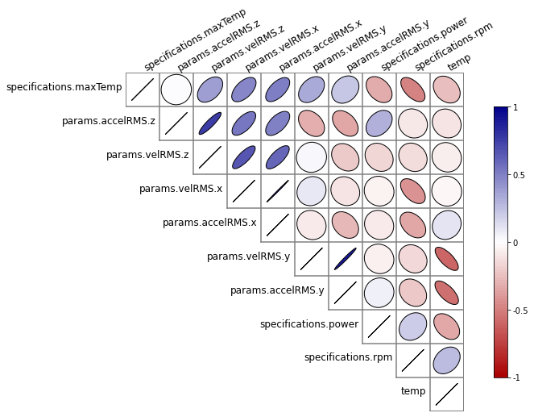

```python
analise = df[['params.velRMS.x','params.velRMS.y','params.velRMS.z','params.accelRMS.x','params.accelRMS.y','params.accelRMS.z','specifications.maxTemp','specifications.rpm','specifications.power','temp']]
from biokit.viz import corrplot
import matplotlib.pyplot as plt

corr_graf = corrplot.Corrplot(analise.corr())
corr_graf.plot(upper='ellipse',fontsize='large')
fig = plt.gcf()
fig.set_size_inches(15,10)
fig.show()
```

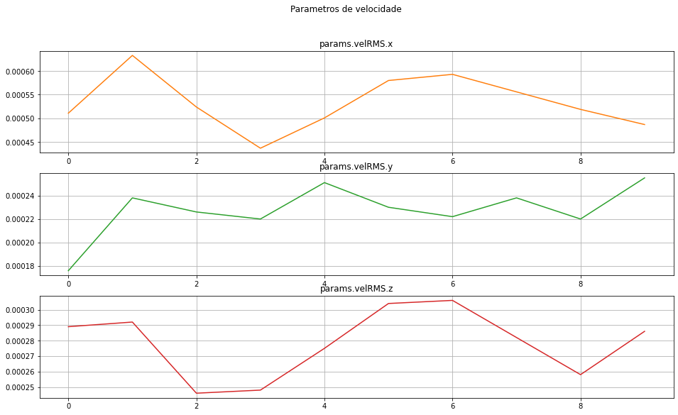

```python
fig, axs = plt.subplots(3,figsize=(16,9))
fig.suptitle('Parametros de velocidade')
axs[0].set_title('params.velRMS.x')
axs[0].plot(df['params.velRMS.x'], 'tab:orange')
axs[0].grid()
axs[1].set_title('params.velRMS.y')
axs[1].plot(df['params.velRMS.y'], 'tab:green')
axs[1].grid()
axs[2].set_title('params.velRMS.z')
axs[2].plot(df['params.velRMS.z'], 'tab:red')
axs[2].grid()
plt.show()
```

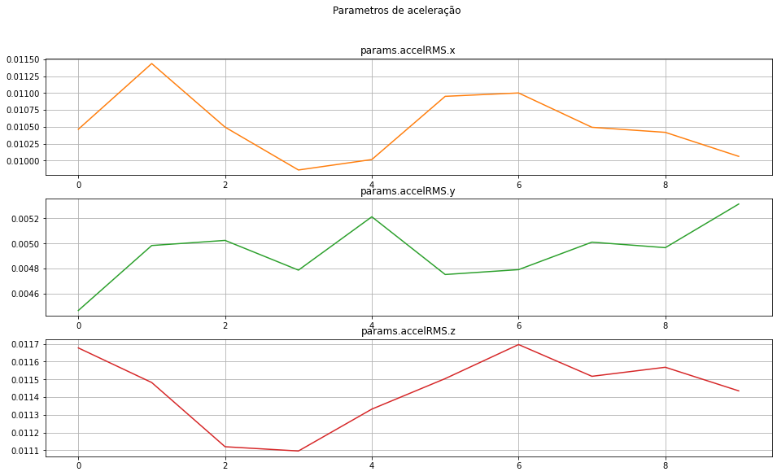

```python
fig, axs = plt.subplots(3,figsize=(16,9))
fig.suptitle('Parametros de aceleração')
axs[0].set_title('params.accelRMS.x')
axs[0].plot(df['params.accelRMS.x'], 'tab:orange')
axs[0].grid()
axs[1].set_title('params.accelRMS.y')
axs[1].plot(df['params.accelRMS.y'], 'tab:green')
axs[1].grid()
axs[2].set_title('params.accelRMS.z')
axs[2].plot(df['params.accelRMS.z'], 'tab:red')
axs[2].grid()
plt.show()
```

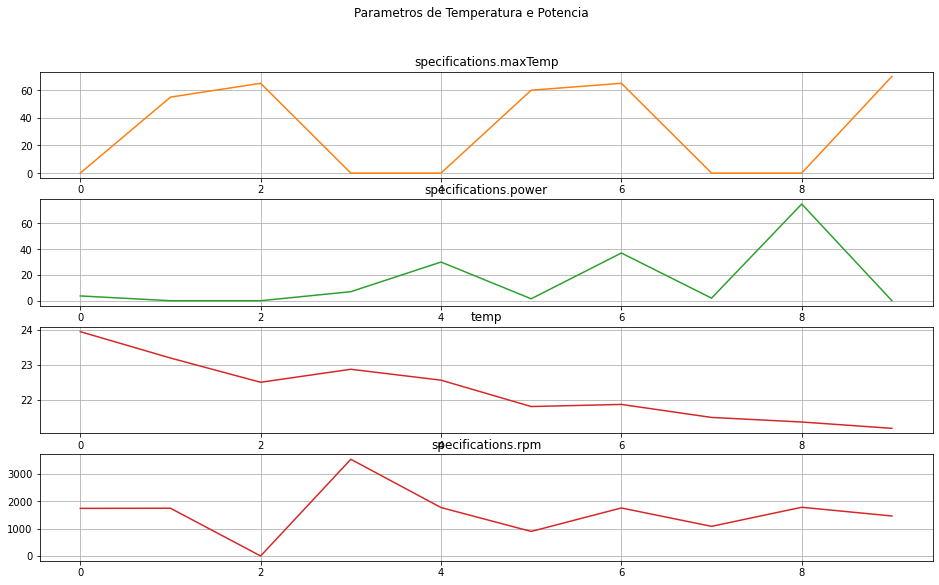

```python
fig, axs = plt.subplots(4,figsize=(16,9))
fig.suptitle('Parametros de Temperatura e Potencia')
axs[0].set_title('specifications.maxTemp')
axs[0].plot(df['specifications.maxTemp'], 'tab:orange')
axs[0].grid()
axs[1].set_title('specifications.power')
axs[1].plot(df['specifications.power'], 'tab:green')
axs[1].grid()
axs[2].set_title('temp')
axs[2].plot(df['temp'], 'tab:red')
axs[2].grid()
axs[3].set_title('specifications.rpm')
axs[3].plot(df['specifications.rpm'], 'tab:red')
axs[3].grid()
plt.show()
```

```python
from sklearn.preprocessing import Normalizer
values = Normalizer().fit_transform(analise.values)
print(values)
```

```
[[2.94495793e-07 1.01431036e-07 1.66554372e-07 6.02995984e-06
  2.57208360e-06 6.72960346e-06 0.00000000e+00 9.99902544e-01
  2.13235701e-03 1.37969262e-02]
 [3.63579243e-07 1.36701200e-07 1.67717439e-07 6.56912448e-06
  2.86210958e-06 6.59497135e-06 3.15906135e-02 9.99412136e-01
  0.00000000e+00 1.33197514e-02]
 [7.61804137e-06 3.28564380e-06 3.57640873e-06 1.52564363e-04
  7.30401524e-05 1.61665305e-04 9.44986048e-01 0.00000000e+00
  0.00000000e+00 3.27110555e-01]
 [1.23968778e-07 6.24099110e-08 7.03529905e-08 2.79681506e-06
  1.35769924e-06 3.14772896e-06 0.00000000e+00 9.99976982e-01
  1.98576989e-03 6.48779393e-03]
 [2.83788523e-07 1.42177483e-07 1.55772143e-07 5.67237179e-06
  2.95287339e-06 6.41894518e-06 0.00000000e+00 9.99773937e-01
  1.69933247e-02 1.27789802e-02]
 [6.47120780e-07 2.56616861e-07 3.39180547e-07 1.22183098e-05
  5.30081176e-06 1.28353059e-05 6.69435289e-02 9.97458581e-01
  1.67358822e-03 2.43339728e-02]
 [3.38521700e-07 1.26731564e-07 1.74684048e-07 6.28006277e-06
  2.73443329e-06 6.67681249e-06 3.71060886e-02 9.99010076e-01
  2.11219273e-02 1.24847716e-02]
 [5.14711951e-07 2.20326339e-07 2.61058939e-07 9.71287372e-06
  4.63796200e-06 1.06617582e-05 0.00000000e+00 9.99800193e-01
  1.85148184e-03 1.99034298e-02]
 [2.92112568e-07 1.23824210e-07 1.45212028e-07 5.86307635e-06
  2.79505013e-06 6.51090210e-06 0.00000000e+00 9.99036241e-01
  4.22127989e-02 1.20278335e-02]
 [3.33599753e-07 1.74677489e-07 1.95912791e-07 6.89188319e-06
  3.64082687e-06 7.83308660e-06 4.79506832e-02 9.98744230e-01
  0.00000000e+00 1.45153568e-02]]
```

```python
from sklearn.cluster import KMeans
kmeans = KMeans(n_clusters=2, n_init=10, max_iter=300)
y_pred = kmeans.fit_predict(values)
```

```python
from sklearn import metrics
labels = kmeans.labels_
silhouette = metrics.silhouette_score(values, labels, metric='euclidean')
print(silhouette)
```

```
0.8751816165657307
```

```python
def clustering_algorithm(n_clusters, dataset):
    kmeans = KMeans(n_clusters=n_clusters, n_init=10, max_iter=300)
    labels = kmeans.fit_predict(dataset)
    s = metrics.silhouette_score(dataset, labels, metric='euclidean')
    dbs = metrics.davies_bouldin_score(dataset, labels)
    calinski = metrics.calinski_harabasz_score(dataset, labels)
    return s, dbs, calinski
```

```python
s1, dbs1, calinski1 = clustering_algorithm(2, values)
print(s1, dbs1, calinski1)
```

```
0.8751816165657307 0.01912603845973986 1926.5163641256572
```

```python
s1, dbs1, calinski1 = clustering_algorithm(2, values)
s2, dbs2, calinski2 = clustering_algorithm(3, values)
s3, dbs3, calinski3 = clustering_algorithm(4, values)
```

```python
import numpy as np
random_data = np.random.rand(1926, 16)
s, dbs, calinski = clustering_algorithm(5, random_data)
print(s, dbs, calinski)
print(s2, dbs2, calinski2)
```

```
0.04322268154669433 3.3393283798666444 71.1238690431167
0.46331665527940624 0.429820758896446 2498.5718904104365
```

```python
set1, set2, set3 = np.array_split(values, 3)
s1, dbs1, calinski1 = clustering_algorithm(2, set1)
s2, dbs2, calinski2 = clustering_algorithm(2, set2)
s3, dbs3, calinski3 = clustering_algorithm(2, set3)
print(s1, dbs1, calinski1)
print(s2, dbs2, calinski2)
print(s3, dbs3, calinski3)
```

```
0.737272924609527 0.01035793192887704 4216.147198883811
0.1566658004364733 0.3538474190966587 2.6622367898112396
0.1683752176462432 0.3895270636461302 2.19686869626195
```

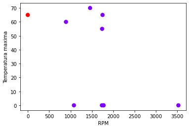

```python
import matplotlib.pyplot as plt
plt.scatter(analise['specifications.rpm'], analise['specifications.maxTemp'], c=labels, s=55, cmap='rainbow')
plt.xlabel("RPM")
plt.ylabel("Temperatura maxima")
plt.show()
```

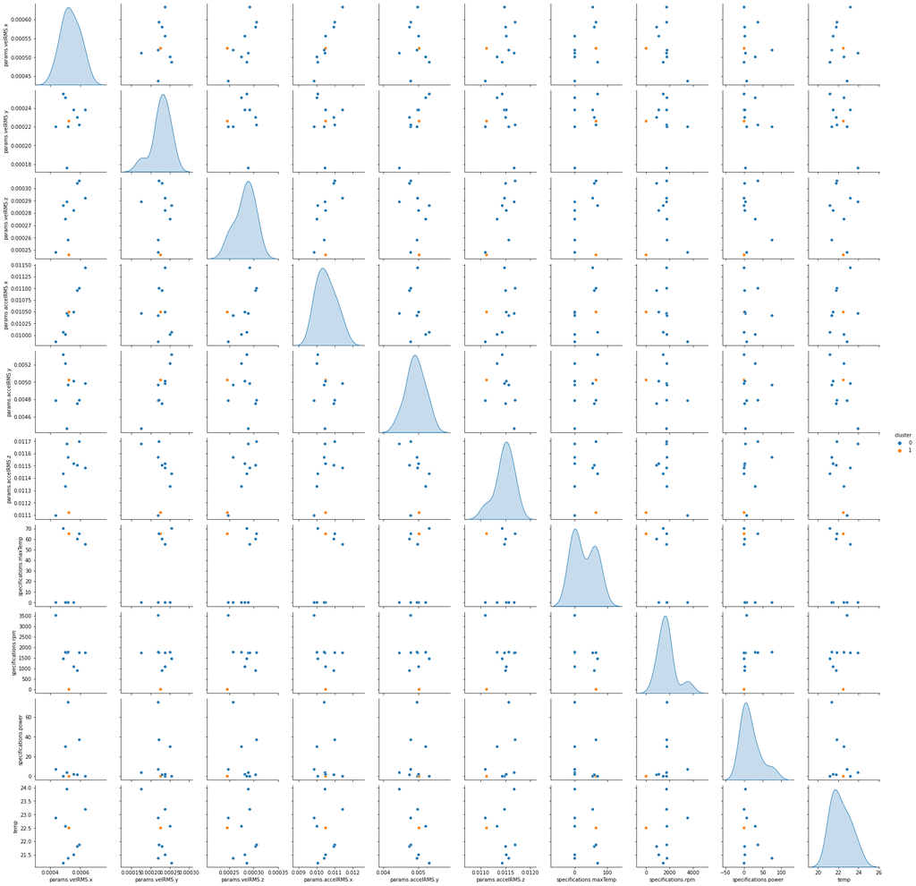

```python
analise["cluster"] = labels
sns.pairplot(analise[0:], hue="cluster")
```

```python
analise.groupby("cluster").describe()
```

| cluster | params.velRMS.x count | params.velRMS.x mean | params.velRMS.x std | params.velRMS.x min | params.velRMS.x 25% | params.velRMS.x 50% | params.velRMS.x 75% | params.velRMS.x max | params.velRMS.y count | params.velRMS.y mean | params.velRMS.y std | params.velRMS.y min | params.velRMS.y 25% | params.velRMS.y 50% | params.velRMS.y 75% | params.velRMS.y max | params.velRMS.z count | params.velRMS.z mean | params.velRMS.z std | params.velRMS.z min | params.velRMS.z 25% | params.velRMS.z 50% | params.velRMS.z 75% | params.velRMS.z max | params.accelRMS.x count | params.accelRMS.x mean | params.accelRMS.x std | params.accelRMS.x min | params.accelRMS.x 25% | … |
| --- | --- | --- | --- | --- | --- | --- | --- | --- | --- | --- | --- | --- | --- | --- | --- | --- | --- | --- | --- | --- | --- | --- | --- | --- | --- | --- | --- | --- | --- | --- |
| 0 | 9.0 | 0.000535 | 0.000061 | 0.000437 | 0.000501 | 0.000519 | 0.000580 | 0.000633 | 9.0 | 0.000228 | 0.000023 | 0.000176 | 0.000220 | 0.000230 | 0.000238 | 0.000255 | 9.0 | 0.000282 | 0.000019 | 0.000248 | 0.000275 | 0.000286 | 0.000292 | 0.000306 | 9.0 | 0.010522 | 0.000522 | 0.009859 | 0.010061 | … |
| 1 | 1.0 | 0.000524 | NaN | 0.000524 | 0.000524 | 0.000524 | 0.000524 | 0.000524 | 1.0 | 0.000226 | NaN | 0.000226 | 0.000226 | 0.000226 | 0.000226 | 0.000226 | 1.0 | 0.000246 | NaN | 0.000246 | 0.000246 | 0.000246 | 0.000246 | 0.000246 | 1.0 | 0.010494 | NaN | 0.010494 | 0.010494 | … |

```python
centroids = kmeans.cluster_centers_
print(centroids)
```

```
[[3.54655454e-07 1.49432899e-07 1.86271700e-07 6.89271966e-06
  3.20598332e-06 7.48990158e-06 2.03989905e-02 9.99234991e-01
  9.77458310e-03 1.44054240e-02]
 [7.61804137e-06 3.28564380e-06 3.57640873e-06 1.52564363e-04
  7.30401524e-05 1.61665305e-04 9.44986048e-01 0.00000000e+00
  0.00000000e+00 3.27110555e-01]]
```

```python
max = len(centroids[0])
for i in range(max):
    print(analise.columns.values[i],"\n{:.4f}".format(centroids[:, i].var()))
```

```
params.velRMS.x
0.0000
params.velRMS.y
0.0000
params.velRMS.z
0.0000
params.accelRMS.x
0.0000
params.accelRMS.y
0.0000
params.accelRMS.z
0.0000
specifications.maxTemp
0.2137
specifications.rpm
0.2496
specifications.power
0.0000
temp
0.0244
```

```python
description = analise.groupby("cluster")['params.velRMS.x','params.velRMS.y','params.velRMS.z','params.accelRMS.x','params.accelRMS.y','params.accelRMS.z','specifications.maxTemp','specifications.rpm','specifications.power','temp']
n_clients = description.size()
description = description.mean()
description['n_clients'] = n_clients
print(description)
```

```
         params.velRMS.x  params.velRMS.y  params.velRMS.z  params.accelRMS.x  \
cluster
0               0.000535         0.000228         0.000282           0.010522
1               0.000524         0.000226         0.000246           0.010494

         params.accelRMS.y  params.accelRMS.z  specifications.maxTemp  \
cluster
0                 0.004920           0.011479               27.777778
1                 0.005024           0.011120               65.000000

         specifications.rpm  specifications.power       temp  n_clients
cluster
0               1746.888889             17.355556  22.255556          9
1                  0.000000              0.000000  22.500000          1
```

```python
analise.groupby("cluster")["specifications.maxTemp"].describe()
```

| cluster | count | mean | std | min | 25% | 50% | 75% | max |
| --- | --- | --- | --- | --- | --- | --- | --- | --- |
| 0 | 9.0 | 27.777778 | 33.176715 | 0.0 | 0.0 | 0.0 | 60.0 | 70.0 |
| 1 | 1.0 | 65.000000 | NaN | 65.0 | 65.0 | 65.0 | 65.0 | 65.0 |